# cola Report for Consensus Partitioning

# cola Report for Consensus Partitioning

**Date**: 2023-05-08 16:12:44 CDT, **cola version**: 2.4.0

## Summary

First the variable is renamed to `res_list`.

```r
res_list = r1
```

All available functions which can be applied to this `res_list` object:

```r
res_list
```

```
#> A 'ConsensusPartitionList' object with 4 methods.
#>   On a matrix with 1217 rows and 1217 columns.
#>   Top rows are extracted by 'SD, MAD' methods.
#>   Subgroups are detected by 'skmeans, kmeans' method.
#>   Number of partitions are tried for k = 2, 3, 4, 5, 6, 7, 8, 9, 10.
#>   Performed in total 1800 partitions by row resampling.
#>
#> Following methods can be applied to this 'ConsensusPartitionList' object:
#>  [1] "cola_report"           "collect_classes"       "collect_plots"         "collect_stats"
#>  [5] "colnames"              "functional_enrichment" "get_anno"              "get_anno_col"
#>  [9] "get_classes"           "get_matrix"            "get_membership"        "get_stats"
#> [13] "is_best_k"             "is_stable_k"           "ncol"                  "nrow"
#> [17] "rownames"              "show"                  "suggest_best_k"        "test_to_known_factors"
#> [21] "top_rows_heatmap"      "top_rows_overlap"
#>
#> You can get result for a single method by, e.g. object["SD", "skmeans"] or object["SD:skmeans"]
#> or a subset of methods by object[c("SD", "MAD")], c("skmeans", "kmeans")]
```

The call of `run_all_consensus_partition_methods()` was:

```
#> run_all_consensus_partition_methods(data = jaccard_similarity_matrix, top_value_method = c("SD",
#>     "MAD"), partition_method = c("skmeans", "kmeans"), max_k = 10)
```

Dimension of the input matrix:

```r
mat = get_matrix(res_list)
dim(mat)
```

```
#> [1] 1217 1217
```

### Density distribution

The density distribution for each sample is visualized as in one column in the following heatmap. The clustering is based on the distance which is the Kolmogorov-Smirnov statistic between two distributions.

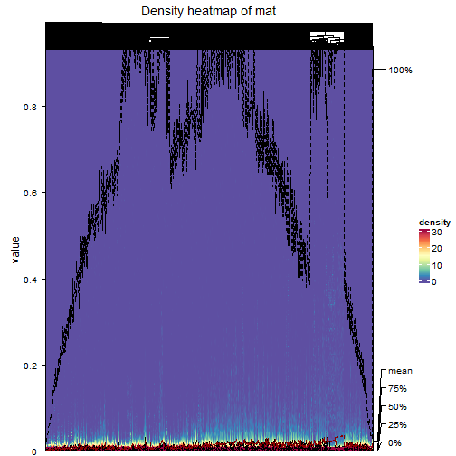

```r
library(ComplexHeatmap)
densityHeatmap(mat, ylab = "value", cluster_columns = TRUE, show_column_names = FALSE,
    mc.cores = 1)
```

### Suggest the best k

Folowing table shows the best `k` (number of partitions) for each combination of top-value methods and partitioning methods. Clicking on the method name in the table goes to the corresponding section for a single combination of methods.

[The cola vignette](https://jokergoo.github.io/cola_vignettes/cola.html#toc_13) explains the definition of the metrics used for determining the best number of partitions.

```r
suggest_best_k(res_list)
```

|  | The best k | 1-PAC | Mean silhouette | Concordance |  | Optional k |
| --- | --- | --- | --- | --- | --- | --- |
| SD:kmeans | 6 | 0.953 | 0.832 | 0.909 | ** |  |
| SD:skmeans | 9 | 0.927 | 0.881 | 0.950 | * | 2,3,4,6,8 |
| MAD:skmeans | 9 | 0.913 | 0.843 | 0.922 | * | 2,3,4,5,6,7,8 |
| MAD:kmeans | 4 | 0.846 | 0.873 | 0.931 |  |  |

**: 1-PAC > 0.95, *: 1-PAC > 0.9

### CDF of consensus matrices

```r
collect_plots(res_list, fun = plot_ecdf)
```

[output not shown]

### Consensus heatmap

- k = 2
- k = 3
- k = 4
- k = 5
- k = 6
- k = 7
- k = 8
- k = 9
- k = 10

```r
collect_plots(res_list, k = 2, fun = consensus_heatmap, cores = 1)
```

[output not shown]

```r
collect_plots(res_list, k = 3, fun = consensus_heatmap, cores = 1)
```

[output not shown]

```r
collect_plots(res_list, k = 4, fun = consensus_heatmap, cores = 1)
```

[output not shown]

```r
collect_plots(res_list, k = 5, fun = consensus_heatmap, cores = 1)
```

[output not shown]

```r
collect_plots(res_list, k = 6, fun = consensus_heatmap, cores = 1)
```

[output not shown]

```r
collect_plots(res_list, k = 7, fun = consensus_heatmap, cores = 1)
```

[output not shown]

```r
collect_plots(res_list, k = 8, fun = consensus_heatmap, cores = 1)
```

[output not shown]

```r
collect_plots(res_list, k = 9, fun = consensus_heatmap, cores = 1)
```

[output not shown]

```r
collect_plots(res_list, k = 10, fun = consensus_heatmap, cores = 1)
```

[output not shown]

### Membership heatmap

- k = 2
- k = 3
- k = 4
- k = 5
- k = 6
- k = 7
- k = 8
- k = 9
- k = 10

```r
collect_plots(res_list, k = 2, fun = membership_heatmap, cores = 1)
```

[output not shown]

```r
collect_plots(res_list, k = 3, fun = membership_heatmap, cores = 1)
```

[output not shown]

```r
collect_plots(res_list, k = 4, fun = membership_heatmap, cores = 1)
```

[output not shown]

```r
collect_plots(res_list, k = 5, fun = membership_heatmap, cores = 1)
```

[output not shown]

```r
collect_plots(res_list, k = 6, fun = membership_heatmap, cores = 1)
```

[output not shown]

```r
collect_plots(res_list, k = 7, fun = membership_heatmap, cores = 1)
```

[output not shown]

```r
collect_plots(res_list, k = 8, fun = membership_heatmap, cores = 1)
```

[output not shown]

```r
collect_plots(res_list, k = 9, fun = membership_heatmap, cores = 1)
```

[output not shown]

```r
collect_plots(res_list, k = 10, fun = membership_heatmap, cores = 1)
```

[output not shown]

### Signature heatmap

Note in following heatmaps, rows are scaled.

- k = 2
- k = 3
- k = 4
- k = 5
- k = 6
- k = 7
- k = 8
- k = 9
- k = 10

```r
collect_plots(res_list, k = 2, fun = get_signatures, cores = 1)
```

[output not shown]

```r
collect_plots(res_list, k = 3, fun = get_signatures, cores = 1)
```

[output not shown]

```r
collect_plots(res_list, k = 4, fun = get_signatures, cores = 1)
```

[output not shown]

```r
collect_plots(res_list, k = 5, fun = get_signatures, cores = 1)
```

[output not shown]

```r
collect_plots(res_list, k = 6, fun = get_signatures, cores = 1)
```

[output not shown]

```r
collect_plots(res_list, k = 7, fun = get_signatures, cores = 1)
```

[output not shown]

```r
collect_plots(res_list, k = 8, fun = get_signatures, cores = 1)
```

[output not shown]

```r
collect_plots(res_list, k = 9, fun = get_signatures, cores = 1)
```

[output not shown]

```r
collect_plots(res_list, k = 10, fun = get_signatures, cores = 1)
```

[output not shown]

### Statistics table

The statistics used for measuring the stability of consensus partitioning. ([How are they defined?](https://jokergoo.github.io/cola_vignettes/cola.html#toc_13))

- k = 2
- k = 3
- k = 4
- k = 5
- k = 6
- k = 7
- k = 8
- k = 9
- k = 10

```r
get_stats(res_list, k = 2)
```

```
#>             k 1-PAC mean_silhouette concordance area_increased  Rand Jaccard
#> SD:skmeans  2 1.000           0.976       0.988          0.354 0.641   0.641
#> MAD:skmeans 2 0.987           0.962       0.984          0.484 0.515   0.515
#> SD:kmeans   2 0.849           0.970       0.975          0.125 0.871   0.871
#> MAD:kmeans  2 0.725           0.906       0.947          0.326 0.667   0.667
```

```r
get_stats(res_list, k = 3)
```

```
#>             k 1-PAC mean_silhouette concordance area_increased  Rand Jaccard
#> SD:skmeans  3 1.000           0.984       0.995          0.214 0.911   0.863
#> MAD:skmeans 3 0.974           0.949       0.980          0.231 0.844   0.709
#> SD:kmeans   3 0.795           0.968       0.977          0.813 0.905   0.891
#> MAD:kmeans  3 0.664           0.717       0.844          0.372 0.812   0.728
```

```r
get_stats(res_list, k = 4)
```

```
#>             k 1-PAC mean_silhouette concordance area_increased  Rand Jaccard
#> SD:skmeans  4 0.917           0.928       0.970          0.245 0.880   0.791
#> MAD:skmeans 4 0.950           0.925       0.968          0.113 0.897   0.754
#> SD:kmeans   4 0.871           0.949       0.964          0.371 0.890   0.859
#> MAD:kmeans  4 0.846           0.873       0.931          0.116 0.894   0.811
```

```r
get_stats(res_list, k = 5)
```

```
#>             k 1-PAC mean_silhouette concordance area_increased  Rand Jaccard
#> SD:skmeans  5 0.840           0.867       0.933         0.1779 0.856   0.693
#> MAD:skmeans 5 0.972           0.934       0.974         0.0504 0.941   0.831
#> SD:kmeans   5 0.980           0.926       0.961         0.1487 0.991   0.986
#> MAD:kmeans  5 0.841           0.843       0.916         0.1155 0.908   0.818
```

```r
get_stats(res_list, k = 6)
```

```
#>             k 1-PAC mean_silhouette concordance area_increased  Rand Jaccard
#> SD:skmeans  6 0.985           0.946       0.975         0.0607 0.977   0.933
#> MAD:skmeans 6 0.939           0.896       0.955         0.0320 0.969   0.899
#> SD:kmeans   6 0.953           0.832       0.909         0.1038 0.936   0.904
#> MAD:kmeans  6 0.726           0.715       0.889         0.1316 0.895   0.767
```

```r
get_stats(res_list, k = 7)
```

```
#>             k 1-PAC mean_silhouette concordance area_increased  Rand Jaccard
#> SD:skmeans  7 0.958           0.918       0.963         0.0260 0.988   0.964
#> MAD:skmeans 7 0.963           0.907       0.959         0.0226 0.974   0.909
#> SD:kmeans   7 0.886           0.885       0.949         0.0751 0.983   0.972
#> MAD:kmeans  7 0.746           0.713       0.879         0.0407 0.934   0.829
```

```r
get_stats(res_list, k = 8)
```

```
#>             k 1-PAC mean_silhouette concordance area_increased  Rand Jaccard
#> SD:skmeans  8 0.915           0.822       0.932         0.0339 0.981   0.941
#> MAD:skmeans 8 0.922           0.836       0.924         0.0258 0.982   0.931
#> SD:kmeans   8 0.839           0.886       0.944         0.1102 0.918   0.864
#> MAD:kmeans  8 0.796           0.725       0.881         0.0578 0.943   0.836
```

```r
get_stats(res_list, k = 9)
```

```
#>             k 1-PAC mean_silhouette concordance area_increased  Rand Jaccard
#> SD:skmeans  9 0.927           0.881       0.950         0.0381 0.936   0.793
#> MAD:skmeans 9 0.913           0.843       0.922         0.0224 0.972   0.888
#> SD:kmeans   9 0.761           0.731       0.910         0.1439 0.959   0.923
#> MAD:kmeans  9 0.802           0.766       0.880         0.0113 0.982   0.943
```

```r
get_stats(res_list, k = 10)
```

```
#>              k 1-PAC mean_silhouette concordance area_increased  Rand Jaccard
#> SD:skmeans  10 0.936           0.875       0.943        0.00871 0.994   0.979
#> MAD:skmeans 10 0.897           0.807       0.907        0.01413 0.991   0.963
#> SD:kmeans   10 0.775           0.791       0.888        0.12045 0.869   0.736
#> MAD:kmeans  10 0.802           0.733       0.866        0.02958 0.971   0.905
```

Following heatmap plots the partition for each combination of methods and the lightness correspond to the silhouette scores for samples in each method. On top the consensus subgroup is inferred from all methods by taking the mean silhouette scores as weight.

- k = 2
- k = 3
- k = 4
- k = 5
- k = 6
- k = 7
- k = 8
- k = 9
- k = 10

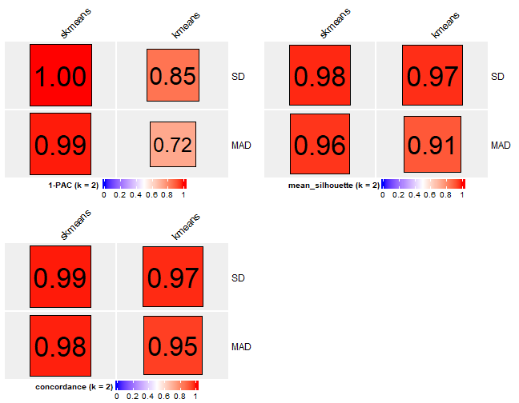

```r
collect_stats(res_list, k = 2)
```

```r
collect_stats(res_list, k = 3)
```

[figure not shown]

```r
collect_stats(res_list, k = 4)
```

[figure not shown]

```r
collect_stats(res_list, k = 5)
```

[figure not shown]

```r
collect_stats(res_list, k = 6)
```

[figure not shown]

```r
collect_stats(res_list, k = 7)
```

[figure not shown]

```r
collect_stats(res_list, k = 8)
```

[figure not shown]

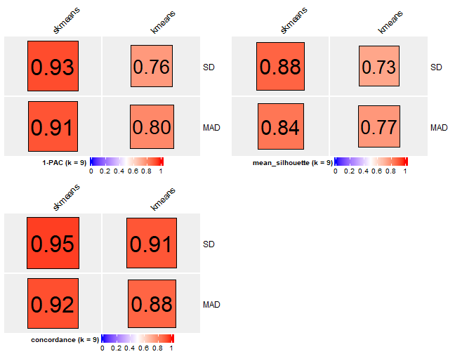

```r
collect_stats(res_list, k = 9)
```

```r
collect_stats(res_list, k = 10)
```

[figure not shown]

### Partition from all methods

Collect partitions from all methods:

- k = 2
- k = 3
- k = 4
- k = 5
- k = 6
- k = 7
- k = 8
- k = 9
- k = 10

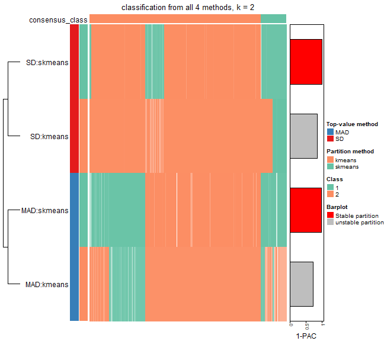

```r
collect_classes(res_list, k = 2)
```

```r
collect_classes(res_list, k = 3)
```

[figure not shown]

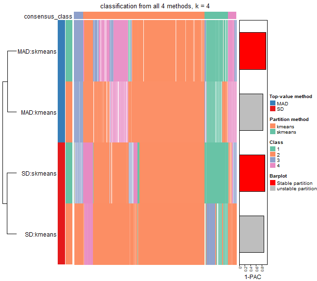

```r
collect_classes(res_list, k = 4)
```

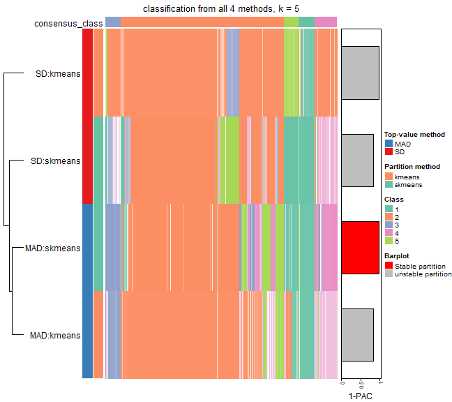

```r
collect_classes(res_list, k = 5)
```

```r
collect_classes(res_list, k = 6)
```

[figure not shown]

```r
collect_classes(res_list, k = 7)
```

[figure not shown]

```r
collect_classes(res_list, k = 8)
```

[figure not shown]

```r
collect_classes(res_list, k = 9)
```

[figure not shown]

```r
collect_classes(res_list, k = 10)
```

[figure not shown]

### Top rows overlap

Overlap of top rows from different top-row methods:

- top_n = 122

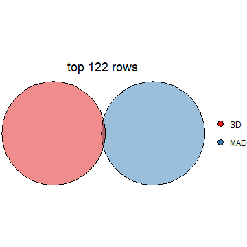

```r
top_rows_overlap(res_list, top_n = 122, method = "euler")
```

Also visualize the correspondance of rankings between different top-row methods:

- top_n = 122

```r
top_rows_overlap(res_list, top_n = 122, method = "correspondance")
```

[figure not shown]

Heatmaps of the top rows:

- top_n = 122

```r
top_rows_heatmap(res_list, top_n = 122)
```

[figure not shown]

[output not shown]

[output not shown]